# TPA03

```python
%matplotlib inline
import math
import scipy
import scipy.stats
import pandas as pd
import matplotlib.pyplot as plt
import numpy as np
import os.path
import seaborn as sns
import statsmodels.formula.api as smf
from statsmodels.graphics.gofplots import ProbPlot
plt.rcParams['figure.figsize']= (20,10) #(15,40)
#from fonctionsUtiles import tracerLHistogrammeNormalise
from sklearn import linear_model
import scipy.io

mat1 = scipy.io.loadmat('/home/foutse/Desktop/TPA_MasterTried/clim_co2_J1982D2010.mat')
mat2 = scipy.io.loadmat('/home/foutse/Desktop/TPA_MasterTried/clim_t2C_J1982D2010.mat')

clmt2 = np.array(mat2['clim_t2'])
data = mat1['clim_co2']
temps = np.arange(1982, 2011, 1.0/12.0)
```

```python
print(clmt2.shape)
#print(clmt2)

#print(temps)
print(np.corrcoef(clmt2[:,2], clmt2[:,3]))
```

```
(348, 11)
[[1.         0.91513152]
 [0.91513152 1.        ]]
```

1.1°) De présenter, sur une même figure, les courbes des températures par ville (soit 9 courbes),

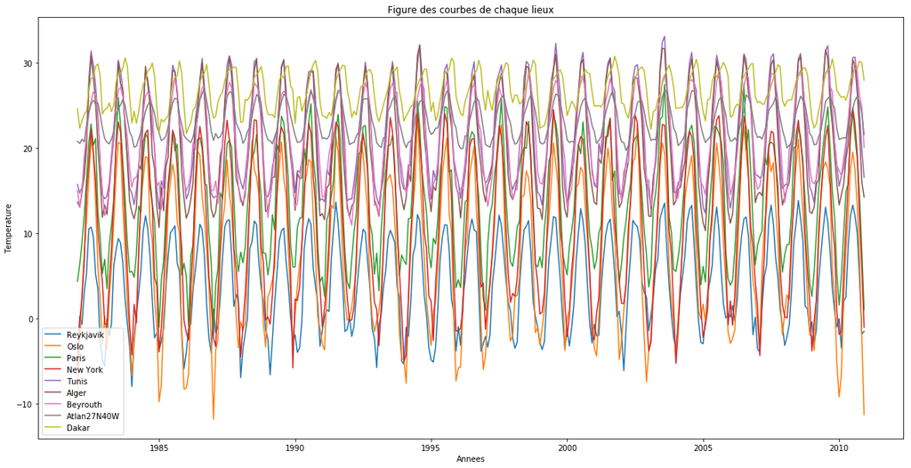

```python
villes = ['Reykjavik','Oslo','Paris','New York','Tunis','Alger', 'Beyrouth','Atlan27N40W','Dakar']
for i in range(9):
    plt.plot( temps, clmt2[:,i+2], label= villes[i])
    plt.legend(loc='best')
    plt.xlabel('Annees')
    plt.ylabel("Temperature")
    plt.title('Figure des courbes de chaque lieux')
plt.show()
```

1.2°) De calculer l’ensemble des coefficients de corrélation linéaires 2 des températures entre les villes prises deux à deux.

```
[[1.         0.91513152 0.89952619 0.94058352 0.90633645 0.91204594
  0.86679125 0.69779896 0.49558449]
 [0.91513152 1.         0.96067357 0.95101465 0.89715115 0.90813973
  0.83547651 0.66122672 0.47139042]
 [0.89952619 0.96067357 1.         0.94131833 0.92993012 0.94357488
  0.86553253 0.71444767 0.53232014]
 [0.94058352 0.95101465 0.94131833 1.         0.94327015 0.94478784
  0.91326285 0.76537713 0.58487927]
 [0.90633645 0.89715115 0.92993012 0.94327015 1.         0.98931468
  0.9513712  0.85369078 0.68451431]
 [0.91204594 0.90813973 0.94357488 0.94478784 0.98931468 1.
  0.92492206 0.82265449 0.64534572]
 [0.86679125 0.83547651 0.86553253 0.91326285 0.9513712  0.92492206
  1.         0.88048643 0.7443007 ]
 [0.69779896 0.66122672 0.71444767 0.76537713 0.85369078 0.82265449
  0.88048643 1.         0.84641347]
 [0.49558449 0.47139042 0.53232014 0.58487927 0.68451431 0.64534572
  0.7443007  0.84641347 1.        ]]
```

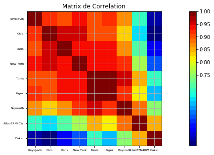

```python
MatCov =np.corrcoef(np.transpose(clmt2[:,2:11]))

print(MatCov)

def correlation_matrix(df):
    from matplotlib import pyplot as plt
    from matplotlib import cm as cm
    fig = plt.figure()
    ax1 = fig.add_subplot(111)
    cmap = cm.get_cmap('jet', 30)
    cax = ax1.imshow(df, interpolation="nearest", cmap=cmap)
    ax1.grid(True)
    plt.title('Matrix de Correlation ')
    labels = ['','Reykjavik','Oslo','Paris','New York','Tunis','Alger', 'Beyrouth','Atlan27N40W','Dakar',]
    ax1.set_xticklabels(labels,fontsize=6)
    ax1.set_yticklabels(labels,fontsize=6)
    # Add colorbar, make sure to specify tick locations to match desired ticklabels
    fig.colorbar(cax, ticks=[.75,.8,.85,.90,.95,1])
    plt.show()

correlation_matrix(MatCov)
```

```python
#plt.scatter(clmt2[:,2],clmt2[:,3],clmt2[:,1])
#print(clmt2[:,1].shape, clmt2[:,2].shape,clmt2[:,3],clmt2[:,1])
print('The shape is:',clmt2[:,2:11].shape)
print('The contente is:',clmt2[:,2:11])#,clmt2[:,2:11][0][0] )-1.4887612903225431
```

```
('The shape is:', (348, 9))
('The contente is:', array([[ -5.44856774,  -9.31565161,   4.37796774, ...,  15.03083871,
         20.81087419,  24.62702581],
       [  0.25263571,  -2.91548214,   6.38400357, ...,  13.06080714,
         20.54066429,  22.32721071],
       [ -0.66882903,   2.99817742,   8.90501935, ...,  14.92567742,
         21.04858065,  23.23344839],
       ...,
       [  4.77168387,   6.89980323,  14.30591613, ...,  26.22144194,
         25.40657097,  30.17650968],
       [ -1.79783   ,  -2.23504333,   7.92683333, ...,  24.82927333,
         24.13824667,  29.99926667],
       [ -1.48876129, -11.24493226,   1.03622581, ...,  20.05807419,
         21.58351613,  27.96020645]]))
```

```python
xbar = []
V = []
for i in range(348):
    V.append(np.mean(np.array(clmt2[:,2:11][i])))
print(np.mean(clmt2[:,2:11][0]))
#print(np.array(V))

#arr = np.loadtxt('/home/foutse/Desktop/TPA_MasterTried/pluie.txt', usecols=(0,1))
#print(arr[1])
```

```
8.185224014336919
```

```python
xbar=[]
V=[]
for i in range(1, 348,12):
        V.append(clmt2[:,2:11][i][0])
        xbar.append( np.mean(V))
print(V)
```

[output not shown]

1.3°) De faire une figures des diagrammes de dispersion des températures par ville deux à deux.

```python
help(plt.text)
```

[output not shown]

```python
from matplotlib import cm
def plotDesFigs(df):
    k= 0
    for i in range(9):
        for j in range(i + 1, 9):
            k +=1
            ax= plt.subplot(9,4,k)
            plt.scatter(df[:,i+2],df[:,j+2], c = df[:,1])
            plt.title(villes[i]+"+"+villes[j])
        #plt.text(-2, 20, round(MatCov[i,j],2), fontdict=None, withdash=False, transform = ax.transAxes)
        #plt.ylabel("tptures")
    #fig = plt.figure()
    plt.subplots_adjust(bottom = 0.1, right = 0.8, top = 0.9)
    c = fig.add_axes([0.65,0.1,0.02,0.8])
    cb = plt.colorbar(cax = c, ticks = range(1,13,1))
    cb.ax.set_yticklabels(['Jan','Fev','Mars','Avril','Mai','Juin', 'Juillet','Aout','Sept'])
    #ax.set_xticklabels(labels,fontsize=6)
    #ax.set_yticklabels(labels,fontsize=6)
    # Add colorbar, make sure to specify tick locations to match desired ticklabels
    #fig.colorbar(cax, ticks=labels)

    return None
```

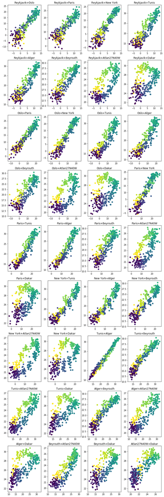

```python
plotDesFigs(clmt2)
```

2) Etude de l’évolution temporelle des températures

```python
t2moy = []
for i in range(348):
    t2moy.append(np.mean(np.array(clmt2[:,2:11][i])))
print(np.mean(clmt2[:,2:11][0]))
np.array(t2moy).shape
#print(t2moy)
tmp = np.arange(1,349)
```

```
8.185224014336919
```

```
(348,)
```

```python
#plt.plot(tmp,t2moy)
```

```python
def caracteriserLesDonnees(x,y):
    #if not(len(x.shape)==1) & not(len(y.shape)==1) & len(x)==len(y)):
    #if ~(isvector(x) & isvector(y) & len(x)==len(y)):
    #    error('Pas coherent avec regression lineaire')

    n     = len(x)
    xMean = np.mean(x)
    sx2   = np.var(x,ddof=0)
    yMean = np.mean(y)
    sy2   = np.var(y,ddof=0)
    cxy   = np.cov(x,y,ddof=0)[0][1]
    #cxy   = scipy.cov(numpy.column_stack((x,y)))

    return n, xMean, yMean, sx2, sy2, cxy

caracteriserLesDonnees(tmp,t2moy)
```

```
(348,
 174.5,
 16.56580820595523,
 10091.916666666666,
 27.62311854855983,
 42.3895315087186)
```

```python
terms = caracteriserLesDonnees(tmp,t2moy)
#print(terms[0])
#print(terms)
print(len(tmp))
#Les parametres
a_o = terms[5]/terms[3]
b_o = terms[2] - a_o * terms[1]
sy2   = np.var(t2moy,ddof=0)
sx2 = terms[3]
YEstime =[]
for i in tmp:
    YEstime.append(b_o + a_o*i )

#print(YEstime)
residue=[]
for i in range(len(tmp)):
    residue.append( t2moy[i] - YEstime[i])

#print(residue)
s = math.sqrt(np.var(residue,ddof=2))
R2= np.var(YEstime)/sy2
```

```
348
```

```
Text(0.5,1,'Temperature Mensieulles Avec la droit de regression')
```

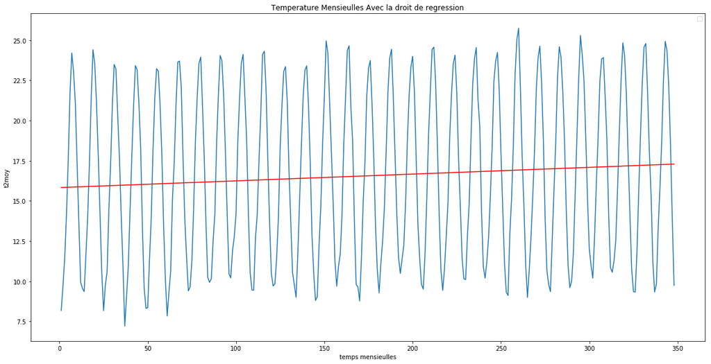

```python
plt.plot(tmp, t2moy)
plt.plot(tmp,YEstime, color='red', )
plt.xlabel("temps mensieulles")
plt.ylabel("t2moy")
plt.legend(loc='best')
plt.title('Temperature Mensieulles Avec la droit de regression')
```

```python
#l’augmentation de la température sur la période selon la régression obtenue est:
L = a_o * (348 - 1)
L
print('laugmentation de la temperature sur la periode', L)
#La prévision de température à 100 ans (pour l’année 2110) dans l’hypothèse ou le changement
#climatique poursuivrait la même évolution (selon la régression obtenue) est:
Y = a_o * (348 + 100*12) + b_o
L2 = a_o * ((348 + 100*12)-1)
print("La prevision de temperature a 100 ans: ", Y)
print('avec une augmentation de: ', L2)
```

```
('laugmentation de la temperature sur la periode', 1.4575197080361695)
('La prevision de temperature a 100 ans: ', 22.334982035890903)
('avec une augmentation de: ', 6.497933683953759)
```

```python
def calculDeLEcartTypeDeA(s,sx2,n):

    return float('nan')

def intervalleDeConfiancePourA(a,n,sx2,s,risque):

    if risque < 0 or risque >1:
        print("probleme de risque")

    # ecart-type de a
    sa = calculDeLEcartTypeDeA(s,sx2,n)

    # ecart de student
    tAlpha_n = scipy.stats.t.ppf(1-risque/2, n-2)

    Ia_inf = a - tAlpha_n*sa
    Ia_sup = a + tAlpha_n*sa

    return Ia_inf,Ia_sup

intervalleDeConfiancePourA(a_o,tmp,sx2,s,0.5)
calculDeLEcartTypeDeA(s,sx2,tmp)
```

```
nan
```

2.2)On souhaite synthétiser davantage l’information, on va supprimer les effets de la variation saisonnière. Pour cela, vous devez créer, à partir de t2moy, un nouveau vecteur : t2moyan qui contient les moyennes annuelles de t2moy, soit 29 valeurs.

```python
k= np.arange(0,349,12)
len(k)
#k
t2moyan=[]
for i in range(29):
    t2moyan.append(np.mean(t2moy[k[i]:k[i+1]]))
t2moyan
#range(29)
len(t2moyan)
#tmp2 = np.arange(1,30)
#plt.plot(tmp2,t2moyan)
```

```
29
```

2.2.a) Comme précédemment, nous vous demandons de présenter la courbe de t2moyan ainsi que la droite de régression obtenue en indiquant les valeurs des coefficients de la droite de régression (b0 et b1).

```python
caracteriserLesDonnees(tmp2,t2moyan)
terms1 = caracteriserLesDonnees(tmp2,t2moyan)
#print(terms[0])
#print(terms)

#Les parametres
a_an = terms1[5]/terms1[3]
b_an = terms1[2] - a_an * terms1[1]
sy2   = np.var(t2moyan,ddof=0)
YEstime =[]
for i in tmp2:
    YEstime.append(b_an + a_an*i )

#print(YEstime)
residue=[]
for i in range(29):
    residue.append( t2moyan[i] - YEstime[i])

#print(residue)
s = math.sqrt(np.var(residue,ddof=2))
R2= np.var(YEstime)/sy2
tmp2 = np.arange(1,30)
```

```
Text(0.5,1,'Temperature Annuelles Avec la droit de regression')
```

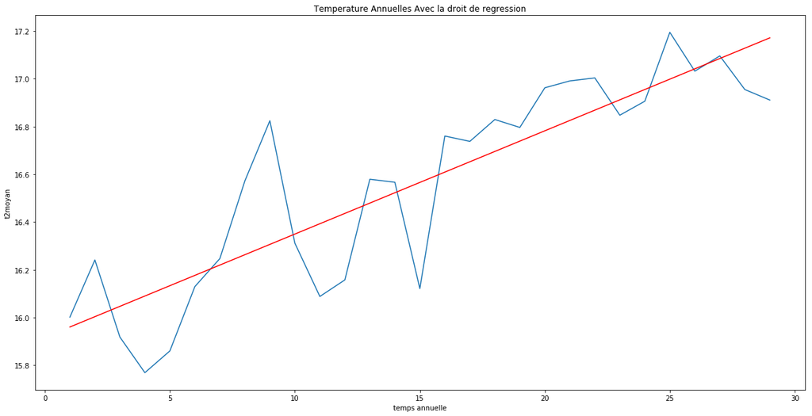

```python
plt.plot(tmp2, t2moyan)
plt.plot(tmp2,YEstime, color='red')
plt.xlabel("temps annuelle")
plt.ylabel("t2moyan")
plt.title('Temperature Annuelles Avec la droit de regression')
```

```python
#l’augmentation de la température sur la période selon la régression obtenue est:
L_an = a_an * 29
L_an
print('laugmentation de la temperature sur la periode', L)
#La prévision de température à 100 ans (pour l’année 2110) dans l’hypothèse ou le changement
#climatique poursuivrait la même évolution (selon la régression obtenue) est:
Y_an = a_an * (29 + 100*12) + b_an
L2_an = a_an * ((29 + 100*12) -1)
print("La prevision de temperature a 100 ans: ",Y_an)
print('avec une augmentation de: ', L2_an)
```

```
('laugmentation de la temperature sur la periode', 1.4575197080361695)
('La prevision de temperature a 100 ans: ', 69.05557444438456)
('avec une augmentation de: ', 53.09508479472094)
```

2.2.b) On veut maintenant restreindre notre étude aux 10 dernières années. On vous demande donc de refaire le même travail en utilisant les moyennes annuelles de t2moyan pour les années 2001 à 2010.

```
Text(0.5,1,'Temperature des 10 derniers annees Avec la droit de regression')
```

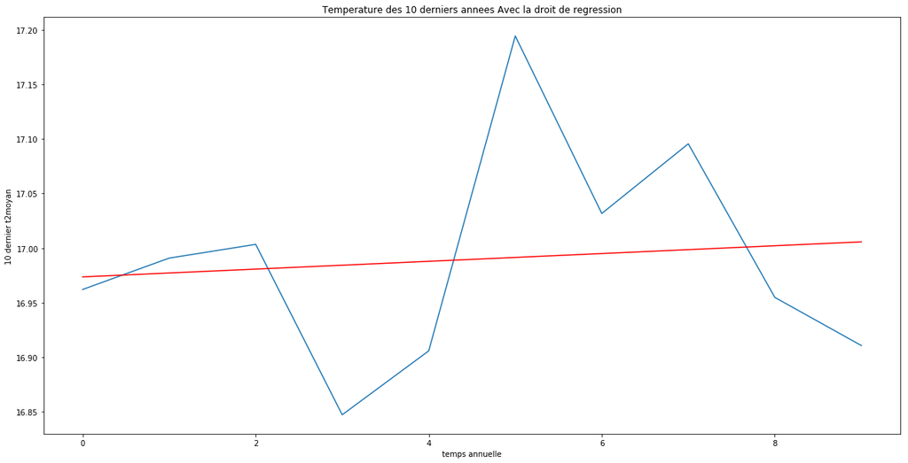

```python
Y = t2moyan[-10:]
t = range(10)
caracteriserLesDonnees(t,Y)
terms1 = caracteriserLesDonnees(t,Y)
#print(terms[0])
#print(terms)

#Les parametres
at = terms1[5]/terms1[3]
bt = terms1[2] - at * terms1[1]
sy2   = np.var(Y,ddof=0)
YEstime =[]
for i in t:
    YEstime.append(bt + at*i )

#print(YEstime)
residue=[]
for i in range(10):
    residue.append( Y[i] - YEstime[i])

#print(residue)
s = math.sqrt(np.var(residue,ddof=2))
R2= np.var(YEstime)/sy2
plt.plot(t, Y)
plt.plot(t,YEstime, color='red')
plt.xlabel("temps annuelle")
plt.ylabel("10 dernier t2moyan")
plt.title('Temperature des 10 derniers annees Avec la droit de regression')
```

```python
#l’augmentation de la température sur la période selon la régression obtenue est:
Lt = at * 10
Lt
print('laugmentation de la temperature sur la periode', L)
#La prévision de température à 100 ans (pour l’année 2110) dans l’hypothèse ou le changement
#climatique poursuivrait la même évolution (selon la régression obtenue) est:
Yt = at * (10 + 100*12) + bt
L2t = at * (10 + 100*12)
print("La prevision de temperature a 100 ans: ", Yt)
print('avec une augmentation de: ', L2t)
```

```
('laugmentation de la temperature sur la periode', 1.4575197080361695)
('La prevision de temperature a 100 ans: ', 21.286628030134818)
('avec une augmentation de: ', 4.3129942688325285)
```